# Problems

## Problem 1

A LED is connected to an arduino, which supplies a voltage of 5V. For a standard LED, the maximum current is usually 20mA. Find the minimum value of the resistance that safely allows to turn on the LED. Assume a built-in potential of $V_{bi}=1.7V$

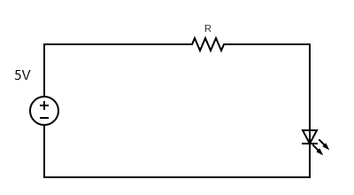

**Solution**:

We assume the LED to be activated with a current flowing clockwise, so we replace the LED by a voltage source of value $V_{bi}=1.7V$. Applying Kirchoff, we have

$$ IR+1.7=5\implies IR=3.3V \implies R_{min}=3.3V/I_{max}=3.3V/20mA=165\Omega$$

```python
3.3/(20*10**(-3))
```

```
165.0
```

## Problem 2

In the following circuit, calculate the Thevenin's equivalent between A and B, and the current going thorough the diode when the resistance is $R=2k\Omega$ and $R=500\Omega$

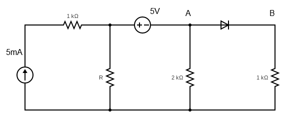

**Solution**

As for the Thevenin's resistance, the resistor of value $R$ and $2k$ are in parallel, and the equivalent of these is in series with the $1k$ resistor. Hence,

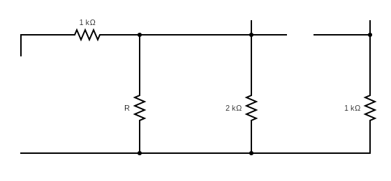

$$ R_{T h}=\frac{2 R}{2+R}+1(\mathrm{k} \Omega) $$

Using mesh analysis, with the left mesh clockwise and the central mesh counterclockwise (the right mesh does not conduct any current due to short circuit)

$$ \begin{aligned} I_{1} &=5 \mathrm{~mA} \\ 5 &=R\left(I_{1}+I_{2}\right)+2 I_{2} \end{aligned} $$

If we now substitute the values of $R$ given,

$R=2k\Omega \implies V_{th}=2.5V,R_{th}=2k\Omega$, and $R=500\Omega \implies V_{th}=-2V,R_{th}=1,4k\Omega$

We now apply the simplified circuits to analyze the state of the diode. For the first value, we assume the diode to be forwardly biased. Then, applying Kirchoff

$$ \begin{array}{l} 2,5=2 I_{D}+0,7 \\ I_{D}=0,9 \mathrm{mA}>0 \end{array} $$

which is consistent.

For the second value, we assume the diode to be with reverse bias, so

$$ \begin{aligned} 2 &=-V_{D}+1,4 I_{D} \\ V_{D} &=-2 \mathrm{V}<0,7 \mathrm{V} \end{aligned} $$

which is consistent.

## Problem 3

Calculate the reading of the voltmeter when the voltage source is V=10V and V=5V

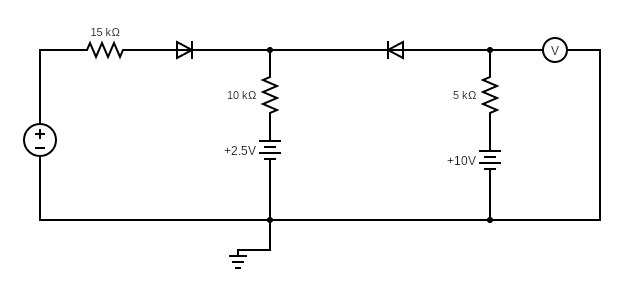

**Solution**:

Let's assume that both diodes are forward biased, and let's employ mesh analysis with clockwise mesh currents.

$$ \begin{array}{l} (10+15) I_{1}+(-10) I_{2}=10-2.5-0.7 \\ (-10)I_{1}+ (10+5) I_{2}=-10+2.5+0.7 \\ \end{array} $$$$ I_{1}=0.12 \mathrm{mA}, I_{2}=-0.37 \mathrm{mA} $$

This solution is consistent with our hypothesis

```python
import numpy as np
from numpy.linalg import solve
A=np.matrix('25,-10;-10,15')
b=np.matrix('6.8;-6.8')
x=solve(A,b)
print(x)
```

```
[[ 0.12363636]
 [-0.37090909]]
```

The voltmeter then measures $V=5I_2+10=-0.37(5)+10=8.145V$

```python
-0.371*5+10
```

```
8.145
```

However, for 5V

$$ \begin{array}{l} (10+15) I_{1}+(-10) I_{2}=5-2.5-0.7 \\ (-10)I_{1}+ (10+5) I_{2}=-10+2.5+0.7 \\ \end{array} $$$$ I_{1}=-0.14 \mathrm{mA}, I_{2}=-0.55 \mathrm{mA} $$

which is not consistent as $I_1<0$.

```python
A=np.matrix('25,-10;-10,15')
b=np.matrix('1.8;-6.8')
x=solve(A,b)
print(x)
```

```
[[-0.14909091]
 [-0.55272727]]
```

Let's then assume that diode on the left mesh is reverse biased,so we are only concerned about the right mesh now. The current must be counterclokwise so

$$(10+5) I=10-2.5-0.7\implies I=0.45mA$$

which is consistent because now the voltage between the diode is $V_D=5-(2.5+0.45(10))=-2V<0.7V$.

The voltmeter measures: $V=5I+10=-0.45(5)+10=7.75V$

```python
5-(2.5+0.45*(10))
```

```
-2.0
```